# Reproducible Research week2 project

## Load and process the data

1. Load the data
2. Process/transform the data (if necessary) into a format suitable for analysis

```r
activityData <- read.csv('activity.csv')
summary(activityData)
```

```
##      steps                date          interval
##  Min.   :  0.00   2012-10-01:  288   Min.   :   0.0
##  1st Qu.:  0.00   2012-10-02:  288   1st Qu.: 588.8
##  Median :  0.00   2012-10-03:  288   Median :1177.5
##  Mean   : 37.38   2012-10-04:  288   Mean   :1177.5
##  3rd Qu.: 12.00   2012-10-05:  288   3rd Qu.:1766.2
##  Max.   :806.00   2012-10-06:  288   Max.   :2355.0
##  NA's   :2304     (Other)   :15840
```

```r
head(activityData)
```

```
##   steps       date interval
## 1    NA 2012-10-01        0
## 2    NA 2012-10-01        5
## 3    NA 2012-10-01       10
## 4    NA 2012-10-01       15
## 5    NA 2012-10-01       20
## 6    NA 2012-10-01       25
```

## What is mean total number of steps taken per day?

1. Calculate the total number of steps taken per day

```r
stepsByDay <- tapply(activityData$steps, activityData$date, sum, na.rm=TRUE)
head(stepsByDay)
```

```
## 2012-10-01 2012-10-02 2012-10-03 2012-10-04 2012-10-05 2012-10-06
##          0        126      11352      12116      13294      15420
```

1. Make a histogram of the total number of steps taken each day

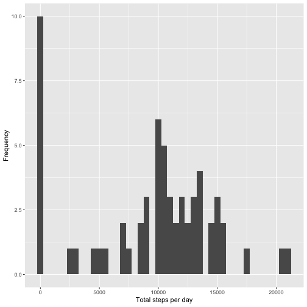

```r
library(ggplot2)
qplot(stepsByDay, xlab='Total steps per day', ylab='Frequency', binwidth=500)
```

1. Calculate and report the mean and median of the total number of steps taken per day

```r
stepsByDayMean <- mean(stepsByDay)
stepsByDayMedian <- median(stepsByDay)
```

- Mean: 9354.2295082
- Median: 10395

## What is the average daily activity pattern?

1. Make a time series plot (i.e.type=“l”) of the 5-minute interval (x-axis) and the average number of steps taken, averaged across all days (y-axis)

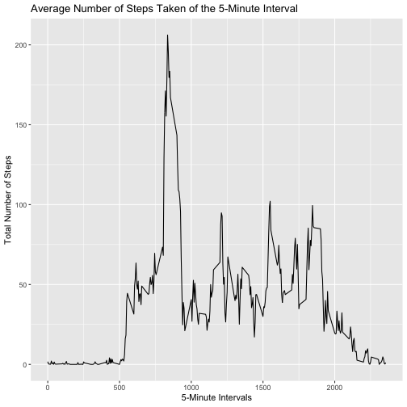

```r
five_min_steps <- aggregate(steps ~ interval, data = activityData, FUN =mean)
ggplot(data = five_min_steps, aes(x = interval, y = steps)) +
    geom_line() +
    xlab("5-Minute Intervals") +
    ylab("Total Number of Steps") +
    ggtitle("Average Number of Steps Taken of the 5-Minute Interval")
```

1. Which 5-minute interval, on average across all the days in the dataset, contains the maximum number of steps?

```r
five_min_steps[which(five_min_steps$steps == max(five_min_steps$steps)),]
```

```
##     interval    steps
## 104      835 206.1698
```

## Imputing missing values

1. Calculate and report the total number of missing values in the dataset (i.e. the total number of rows with NAs)

```r
sum(is.na(activityData$steps))
```

```
## [1] 2304
```

1. Devise a strategy for filling in all of the missing values in the dataset – using mean for that 5-minute interval
2. Create a new dataset that is equal to the original dataset but with the missing data filled in.

```r
library(dplyr)
replace_with_mean <- function(num) replace(num, is.na(num), mean(num, na.rm = TRUE))
activityDataImputed <- (activityData %>% group_by(interval) %>% mutate(steps = replace_with_mean(steps)))
head(activityDataImputed)
```

```
## # A tibble: 6 x 3
## # Groups:   interval [6]
##    steps date       interval
##    <dbl> <fct>         <int>
## 1 1.72   2012-10-01        0
## 2 0.340  2012-10-01        5
## 3 0.132  2012-10-01       10
## 4 0.151  2012-10-01       15
## 5 0.0755 2012-10-01       20
## 6 2.09   2012-10-01       25
```

1. Make a histogram of the total number of steps taken each day and Calculate and report the mean and median total number of steps taken per day.

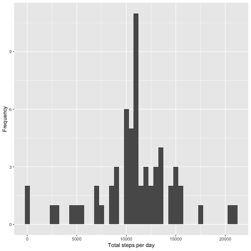

```r
totalStepsImputed <- tapply(activityDataImputed$steps, activityDataImputed$date, sum)
qplot(totalStepsImputed, xlab='Total steps per day', ylab='Frequency', binwidth=500)
```

```r
meanStepsImputed <- mean(totalStepsImputed)
medianStepsImputed <- median(totalStepsImputed)
```

- Mean: 1.0766189 × 10<sup>4</sup>
- Median: 1.0766189 × 10<sup>4</sup>

## Are there differences in activity patterns between weekdays and weekends?

```r
activityDataImputed$WeekendOrWeekday <- ifelse(weekdays(as.Date(activityDataImputed$date)) %in% c("Monday", "Tuesday", "Wednesday", "Thursday", "Friday"), "Weekday", "Weekend")
head(activityDataImputed)
```

```
## # A tibble: 6 x 4
## # Groups:   interval [6]
##    steps date       interval WeekendOrWeekday
##    <dbl> <fct>         <int> <chr>
## 1 1.72   2012-10-01        0 Weekday
## 2 0.340  2012-10-01        5 Weekday
## 3 0.132  2012-10-01       10 Weekday
## 4 0.151  2012-10-01       15 Weekday
## 5 0.0755 2012-10-01       20 Weekday
## 6 2.09   2012-10-01       25 Weekday
```

1. Make a panel plot containing a time series plot (i.e. type=“l”) of the 5-minute interval (x-axis) and the average number of steps taken, averaged across all weekday days or weekend days (y-axis).

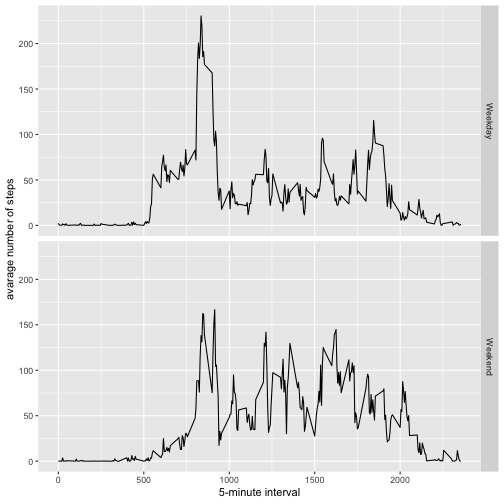

```r
averagedActivityDataImputed <- aggregate(steps ~ interval + WeekendOrWeekday, data=activityDataImputed, mean)
ggplot(averagedActivityDataImputed, aes(interval, steps)) +
    geom_line() +
    facet_grid(WeekendOrWeekday ~ .) +
    xlab("5-minute interval") +
    ylab("avarage number of steps")
```